In Vitro Extra Results Report

Figure guide for fit_invitro_O2G_buffering_500seed

# In Vitro Extra Results Report

**Run:** fit_invitro_O2G_buffering_500seed  
**Detected mode:** fit_invitro  
**Source directory:** `/share/lab_crd/lab_crd/taoli/Project/miningcloneid/oxygen/results/fit_invitro_O2G_buffering_500seed/extra_results`  
**Generated at:** 2026-05-18 13:54:43 EDT

## Parameter Summary

One row per current active or estimated parameter across all seeds. The parameter_description column comes from the run parameter table snapshot.

| parameter | parameter_description | estimated | active_seed_count | seed_count | min_value | median_value | max_value | min_rel_dist_to_bound | boundary_status |
| --- | --- | --- | --- | --- | --- | --- | --- | --- | --- |
| alpha_o2 | soft oxygen-mediated high-ploidy growth penalty strength | TRUE | 500 | 500 | 0.500 | 0.500 | 1.721 | 0 | at_lower, interior, near_lower |
| buffer_beta | ploidy-buffering strength for symmetric missegregation survival | TRUE | 500 | 500 | 0.337 | 1.793 | 7.798 | 0.036 | interior, near_upper |
| buffer_n_exp | ploidy-buffering exponent for symmetric missegregation survival | TRUE | 500 | 500 | 2.618 | 3.744 | 9.485 | 0.011 | interior, near_upper |
| buffer_smax | maximum per-copy survival factor for symmetric buffering missegregation survival | TRUE | 500 | 500 | 0.831 | 1 | 1 | 0 | at_upper, interior |
| gamma_growth | exponent for the soft oxygen-mediated ploidy growth penalty | TRUE | 500 | 500 | 1.500 | 1.500 | 4.319 | 0 | at_lower, interior, near_lower |
| gamma_mu | exponent for high-ploidy hypoxia death above diploid reference | TRUE | 500 | 500 | 1.213 | 2.274 | 3.464 | 0.006 | interior, near_upper, near_lower |
| init_mean_2N | initial 2N-cohort Gaussian chromosome-count mean from early normoxic karyotypes | TRUE | 500 | 500 | 45.725 | 45.844 | 46.717 | 0 | near_lower, at_lower, interior |
| init_mean_4N | initial 4N-cohort Gaussian chromosome-count mean from early normoxic karyotypes | TRUE | 500 | 500 | 83.667 | 83.961 | 86.677 | 0 | near_lower, at_lower, interior |
| init_sd_2N | initial 2N-cohort Gaussian chromosome-count SD from early normoxic karyotypes | TRUE | 500 | 500 | 1.259 | 3 | 3 | 0 | near_upper, at_upper, interior |
| init_sd_4N | initial 4N-cohort Gaussian chromosome-count SD from early normoxic karyotypes | TRUE | 500 | 500 | 3.441 | 5.452 | 6 | 0 | interior, near_upper, at_upper |
| k_o | baseline growth saturation scale in percent O2 | TRUE | 500 | 500 | 0.001 | 10.475 | 39.159 | 0.023 | interior, near_lower, near_upper |
| k_o_mis | half-saturation scale for death-linked missegregation amplification in day^-1 | TRUE | 500 | 500 | 1.04e-05 | 0.001 | 0.018 | 0.005 | interior, near_lower, near_upper |
| lam_max | maximum division rate lam_max in day^-1 | TRUE | 500 | 500 | 0.802 | 1.500 | 1.500 | 0 | at_upper, near_upper, interior |
| lam_min | baseline division rate lam_min in day^-1 | TRUE | 500 | 500 | 0.341 | 0.800 | 0.800 | 0 | at_upper, near_upper, interior |
| mu_hp | soft thresholded high-ploidy hypoxia death strength in day^-1 | TRUE | 500 | 500 | 1e-05 | 1.67e-04 | 0.004 | 0 | interior, near_lower, at_lower |
| n_O | Hill exponent for the oxygen-response weight | TRUE | 500 | 500 | 0.116 | 0.507 | 4.998 | 4.53e-04 | near_lower, interior, near_upper |
| O2_crit | Hill critical oxygen scale for the oxygen-response weight | TRUE | 500 | 500 | 1.02e-04 | 0.023 | 2.482 | 0.001 | interior, near_upper, near_lower |
| p_mis_base | fixed baseline per-chromosome missegregation probability | TRUE | 500 | 500 | 1.01e-06 | 1.27e-04 | 0.005 | 0 | interior, near_lower, at_upper |
| p_misseg | stress-linked missegregation amplification scale | TRUE | 500 | 500 | 0.007 | 0.044 | 0.400 | 0 | interior, at_upper, near_upper |
| p_wgd | whole-genome doubling probability | TRUE | 500 | 500 | 4.66e-05 | 0.001 | 0.001 | 0 | interior, at_upper, near_upper |
| sigma_growth | shared standard deviation of growth-rate observations in the in vitro likelihood | TRUE | 500 | 500 | 0.241 | 0.250 | 0.428 | 0.123 | interior |
| sigma_kary | shared standard deviation of chromosome-count observation error used to smooth the model-predicted N distribution before evaluating the in vitro likelihood | TRUE | 500 | 500 | 0.010 | 0.061 | 1.450 | 0.006 | interior, near_lower |

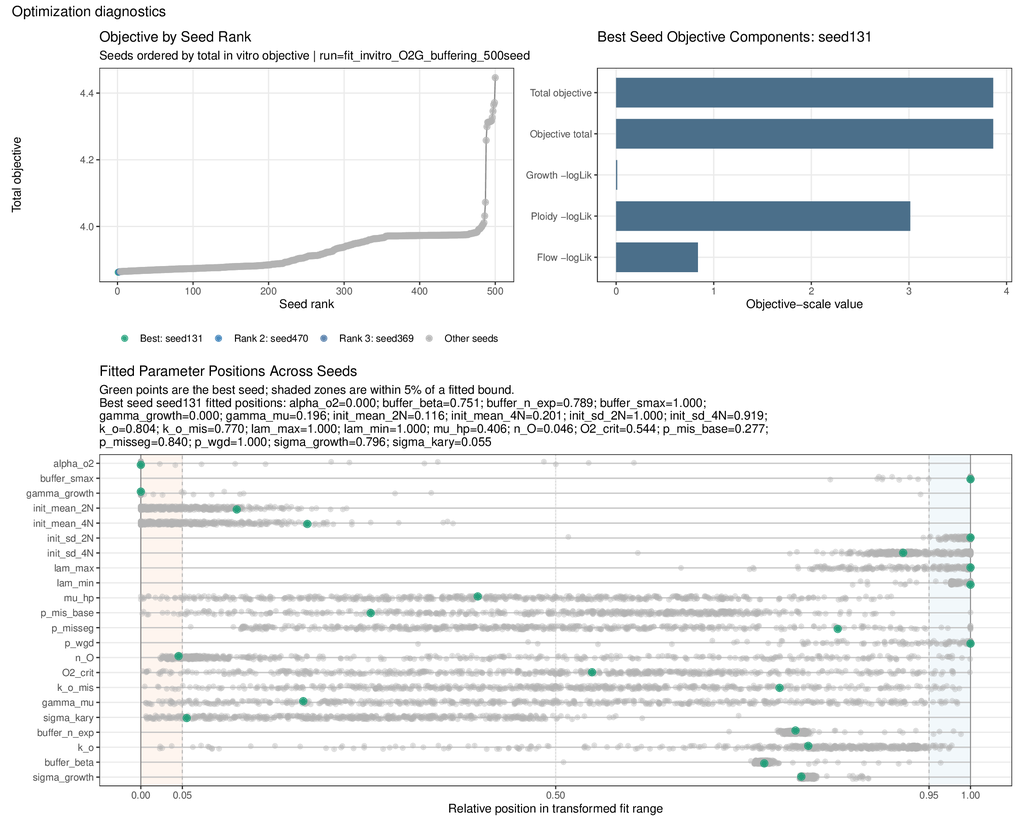

## Figure 1. Optimization Diagnostics

All-seed in vitro optimization diagnostics based on the current run outputs. Source data are saved in this extra_results directory as seed_summary.tsv and parameter_boundary_long.tsv.

`optimization_diagnostics.pdf`

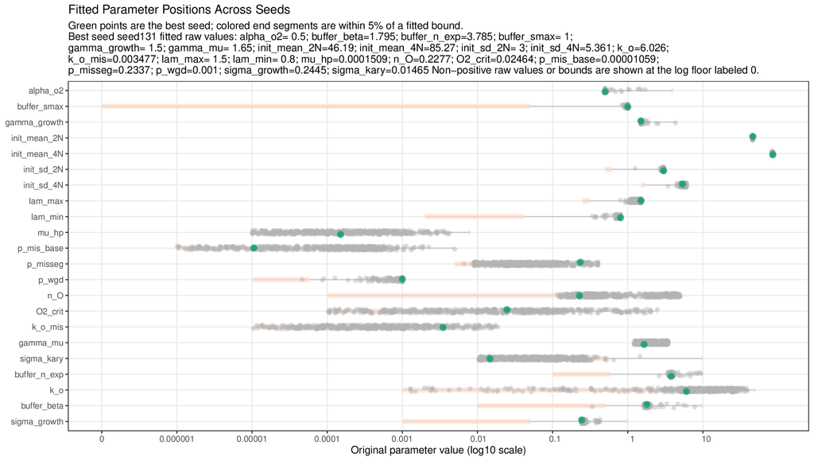

## Figure 2. Fitted Parameter Positions (Log X Scale)

All-seed in vitro fitted-parameter positions shown as original parameter values on a log10 x-axis. This is the parameter panel from Optimization Diagnostics only; non-positive raw values or bounds are floored and labeled 0.

`invitro_parameter_positions_log_x.pdf`

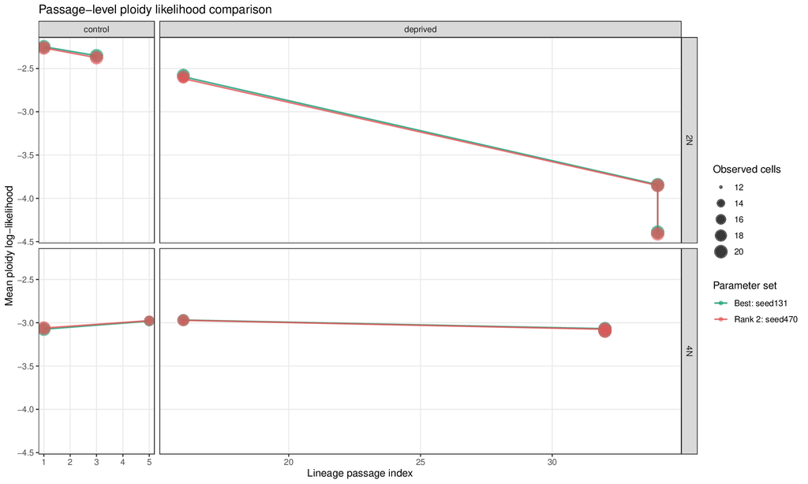

## Figure 3. Best-Fit Ploidy Likelihood Comparison

Passage-level ploidy likelihood comparison for the best available seed-level parameter sets. Source data are saved in best_fit_likelihood_comparison.tsv and best_fit_ploidy_likelihood_comparison_long.tsv.

`best_fit_ploidy_likelihood_comparison.pdf`

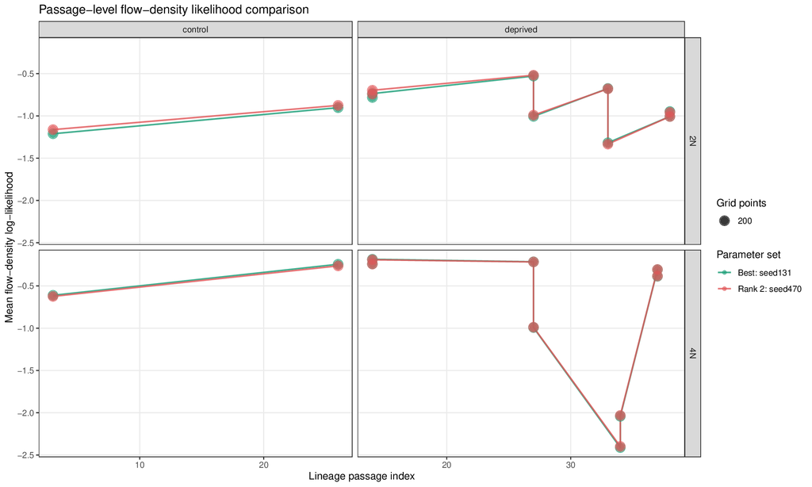

## Figure 4. Best-Fit Flow-Density Likelihood Comparison

Passage-level processed flow-density likelihood comparison for the best available seed-level parameter sets. Source data are saved in best_fit_likelihood_comparison.tsv and best_fit_flow_likelihood_comparison_long.tsv.

`best_fit_flow_likelihood_comparison.pdf`

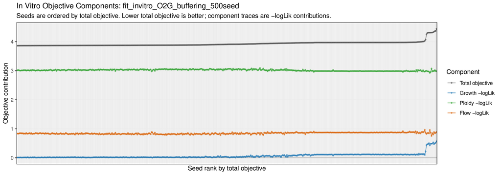

## Figure 5. In Vitro Objective Components

Seed-level total in vitro objective and growth, ploidy, and flow negative log-likelihood contributions. Lower total objective is better.

`invitro_objective_components.pdf`

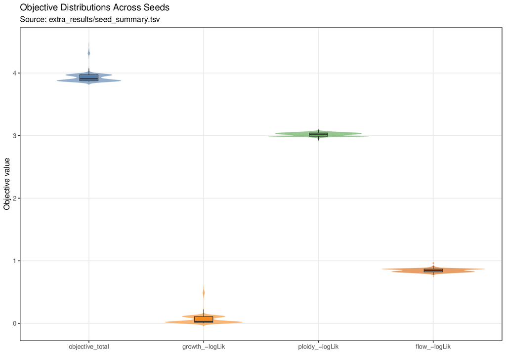

## Figure 6. In Vitro Objective Component Distributions

Across-seed distributions of the total in vitro objective and the in vitro growth, ploidy, and flow negative log-likelihood components.

`objective_components_violin.pdf`

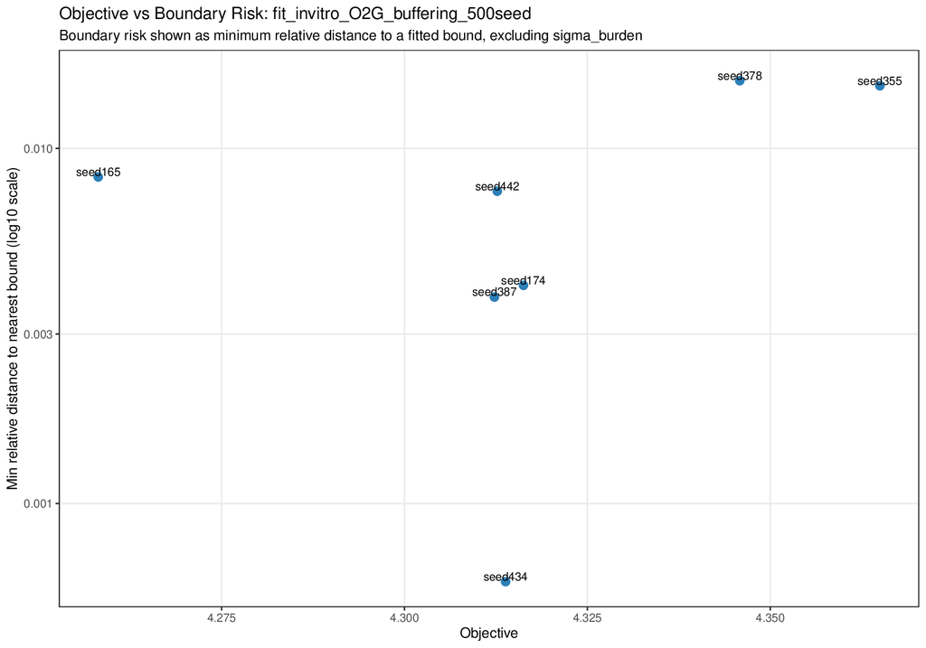

## Figure 7. In Vitro Objective vs Boundary Risk

Total in vitro objective against minimum relative distance to the nearest fitted parameter bound.

`objective_vs_boundary_risk.pdf`

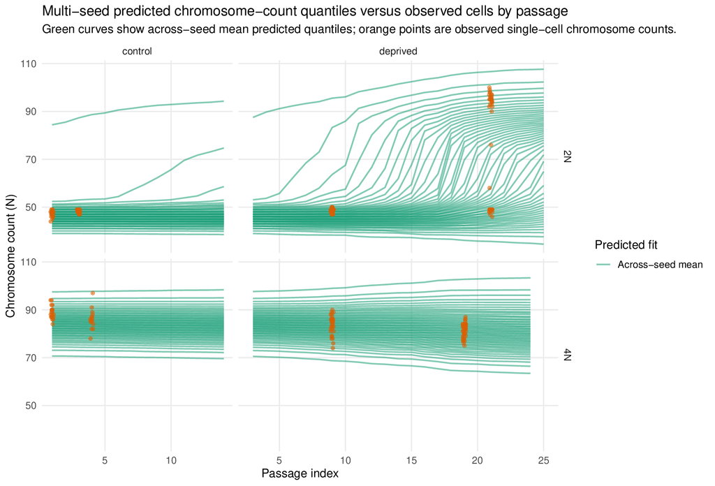

## Figure 8. Multi-Seed Predicted Chromosome-Count Quantiles vs Observed Cells

Across-seed version of the predicted chromosome-count quantile timecourse shown in simulation_basics.html. Panels are split by 2N/4N and control/deprived; green curves show predicted quantiles by passage and orange points show observed single cells.

`invitro_karyotype_quantiles_multiseed.pdf`